# Tarea-04

## Pruebas visuales y Permutación

#### Pruebas de permutación

1. La tabla de datos *Phillies2009* contiene información de la temporada de baseball 2009 para el equipo de Philadelphia *Phillies*, en este ejercicio queremos comparar los strikes (`StrikeOuts`) entre los juegos en casa y de visitante:

```r
# Lectura de datos
phillies <- read_csv("Phillies2009.csv")
```

- Realiza un *lineup* donde cada panel muestre un diagrama de caja y brazos para la variable de interés separando los juegos jugados en casa (home) y los juegos jugados fuera (away). ¿Puedes localizar los datos verdaderos entre los nulos?

R: No pude localizar los datos. Pensé que estaban en el 2 pero están en el 10.

```r
# queremos comparar los strikes (StrikeOuts) entre los juegos en casa y de visitante
location_tbl <- phillies %>%
  select(StrikeOuts, Location)
set.seed(1357)
location_tbl <- lineup(null_permute("Location"), location_tbl, n = 20)
```

```
decrypt("oIL3 PbBb WN yvSWBWvN sh")
```

```r
# decrypt("oIL3 PbBb WN yvSWBWvN sh")
```

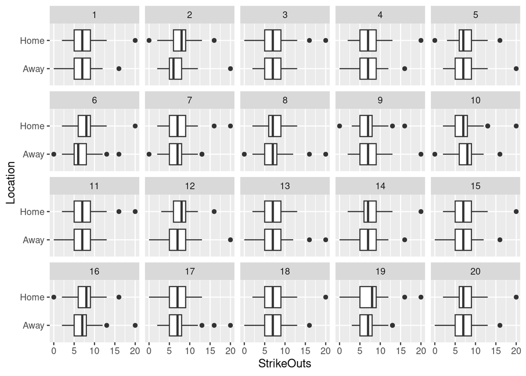

```r
ggplot(location_tbl, aes(y=Location, x=StrikeOuts)) +
  geom_boxplot() +
  facet_wrap(~.sample)
```

- Calcula el promedio de strikes por juego en cada grupo (donde grupo se define por Location).

```r
prom_strikeouts<- phillies %>%
  group_by(Location) %>%
  summarise(prom=mean(StrikeOuts, na.rm=T)) %>%
  ungroup() %>%
  pivot_wider(names_from = Location, values_from = prom) %>%
  mutate(diferencia = Away-Home)
prom_strikeouts
```

```
# A tibble: 1 × 3
   Away  Home diferencia
  <dbl> <dbl>      <dbl>
1  7.31  6.95      0.358
```

- Realiza una prueba de permutación para la diferencia de las medias. Grafica la distribución de referencia y calcula el valor *p* de dos colas.

```r
set.seed(9283)
perms_strikeout <- lineup(null_permute("StrikeOuts"),
                        phillies%>%select(Location,StrikeOuts),
                        n = 5000)
```

```
decrypt("oIL3 PbBb WN yvSWBWvN 5TAs")
```

```r
# decrypt("oIL3 PbBb WN yvSWBWvN 5TAs")

resumen <- perms_strikeout %>% group_by(.sample, Location) %>%
  summarise(media = mean(StrikeOuts)) %>%
  pivot_wider(names_from = Location, values_from = media) %>%
  mutate(dif_home_away = Away - Home)
```

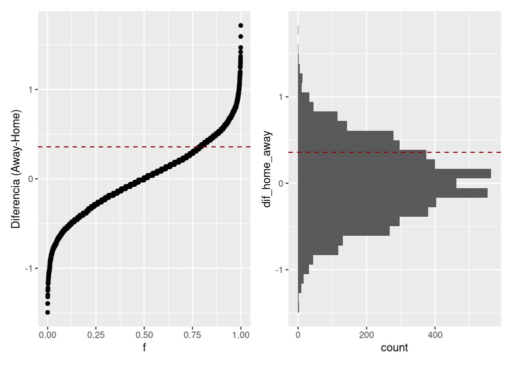

```r
a <- ggplot(resumen, aes(sample=dif_home_away)) +
  geom_qq(distribution = stats::qunif) +
  xlab("f") +
  ylab("Diferencia (Away-Home)") +
  geom_hline(yintercept = prom_strikeouts$diferencia,
             linetype ='dashed', color='darkred')
b <- ggplot(resumen, aes(y=dif_home_away)) +
  geom_histogram() +
  geom_hline(yintercept = prom_strikeouts$diferencia,
             linetype ='dashed', color='darkred')

a + b
```

```r
dist_ref <- ecdf(resumen$dif_home_away)
valor_p <- 2 * min(dist_ref(prom_strikeouts$diferencia),
                   (1 - dist_ref(prom_strikeouts$diferencia)))
valor_p
```

```
[1] 0.4084
```

## Pruebas pareadas

En este ejemplo buscamos comparar la diferencia entre dos medicinas para dormir.

- ID es el identificador de paciente, group el identificador de la medicina, y extra son las horas extras de sueño.

- Examina los datos.

```r
str(sleep)
```

```
'data.frame':   20 obs. of  3 variables:
 $ extra: num  0.7 -1.6 -0.2 -1.2 -0.1 3.4 3.7 0.8 0 2 ...
 $ group: Factor w/ 2 levels "1","2": 1 1 1 1 1 1 1 1 1 1 ...
 $ ID   : Factor w/ 10 levels "1","2","3","4",..: 1 2 3 4 5 6 7 8 9 10 ...
```

La pregunta de interés es si una medicina es mejor que otra para prolongar el sueño. Nótese que en este caso, no tenemos grupos, sino mediciones repetidas.

- Escribe la hipótesis nula.

La media de diferencias (por pares) es igual a cero.

$H_0: \mu_d = 0$

vs

$Ha: \mu_d ≠0$

- Nuestra estadística de interés es media de las diferencias entre las medicinas. Calcula la diferencia observada.

```r
sleep_dif <-sleep %>%
  pivot_wider(id_cols=ID, names_from=group, values_from = extra) %>%
  rename(uno="1", dos="2") %>%
  mutate(dif_extra=uno-dos)

sleep_dif %>%
  select(dif_extra) %>%
  summarise(prom_dif=mean(dif_extra, na.rm=T))
```

```
# A tibble: 1 × 1
  prom_dif
     <dbl>
1    -1.58
```

- Hay variación entre los pacientes. ¿Tenemos evidencia para rechazar que son iguales? ¿Cómo hacemos nuestra distribución de referencia?

```r
set.seed(6483)
perms_sleep <- lineup(null_permute("extra"),
                        sleep,
                        n = 5000)
```

```
decrypt("oIL3 PbBb WN yvSWBWvN shJf")
```

```r
# decrypt("oIL3 PbBb WN yvSWBWvN shJf")
```

```r
resumen_sleep <- perms_sleep %>% group_by(.sample) %>%
  pivot_wider(id_cols=c(.sample, ID), names_from = group, values_from = extra) %>%
  rename(uno="1", dos="2") %>%
  mutate(dif_extra=uno-dos) %>%
  group_by(.sample) %>%
  summarise(dif_prom=mean(dif_extra))
```

- Haz una gráfica de la distribución de referencia y grafica encima el valor observado en los datos originales.

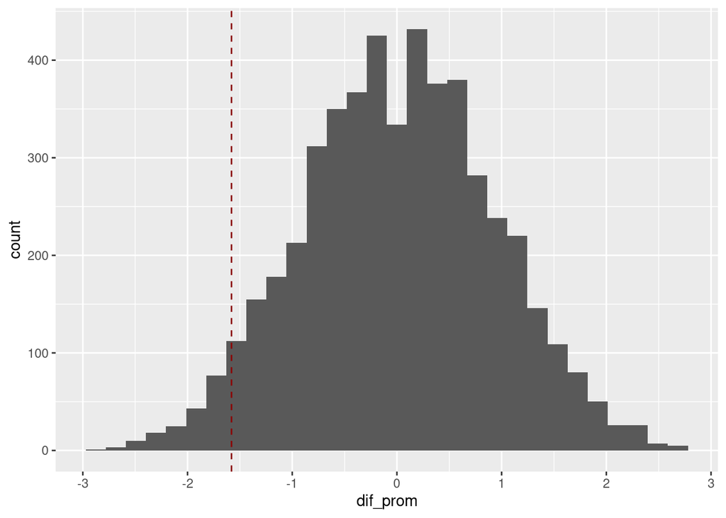

```r
ggplot(resumen_sleep, aes(x=dif_prom)) +
  geom_histogram() +
  geom_vline(xintercept = mean(sleep_dif$dif_extra), linetype='dashed', color='darkred')
```

- Calcula el valor p (justifica porque a una o dos colas).

Es a dos colas porque estamos probando la desigualdad, por lo que le damos oportunidad de ir a ambos lados jeje. En este caso, todo parece indicar que no rechazamos la hipotesis nula. Algo me dice que nos están timando con esa medicina para dormir jejeje. Es el hecho de que la gente cree que toma algo para dormir.

```r
dist_ref_sleep <- ecdf(resumen_sleep$dif_prom)
valor_p_sleep <- 2 * min(dist_ref_sleep(mean(sleep_dif$dif_extra, na.rm=T)),
                   (1 - dist_ref_sleep(mean(sleep_dif$dif_extra, na.rm=T))))
valor_p_sleep
```

```
[1] 0.0812
```

## Valores-*p (opcional)*

Cuando usamos simulación para pruebas de permutación, el valor-*p* de una cola se puede calcular como

$$\hat{P}=(X+1)/(N+1)$$
donde $X$ es el número de estadísticas de prueba remuestreadas que son al menos tan extremas como la observada. Supongamos que el verdadero valor *p* (si pudiéramos hacer todas las permutaciones de manera exhaustiva) es $p$

- ¿Cuál es la varianza de $\hat{P}$?

IDK…
$$Var(\hat{P})= \hat{P}*(1-\hat{P})/(N+1)$$

- ¿Cuál es la varianza de $\hat{P_2}$ para la prueba de dos lados? (suponiendo que $p$ no es cercano a $0.5$, donde $p$ es el verdadero valor *p* para la prueba de una cola).

IDK.. la misma?

## Pruebas de hipótesis *(opcional)*

Ve el video [Is Most Published Research Wrong?](https://www.youtube.com/watch?v=42QuXLucH3Q)

Uno recibiendo bullying y abusos por hacer mal las pruebas de hipótesis y resulta que hasta las que están bien hechas se pueden hackear.